# IC11-2: Case 31 Summary of Data Analysis

R1, R2, R5, & R6 | Employees Federal Credit Union

Ron Stephen Sabilla

2026-11-08

# Introduction

## Employees Federal Credit Union (EFCU)

- EFCU is the credit union for employees of a Fortune 500 company.
- This presentation covers the **introductory-level research questions**: R1, R2, R5, and R6.
- The analysis uses the cleaned data I prepared in IC10-2-1 (`Case 31 Data_efcu_1_RSS_cleaned.sav`).

## Problem Definition

- EFCU has a large amount of **surplus funds**.
- Its **loan/share ratio is lower** than other credit unions of similar size. Members save there but don’t borrow there.
- Average earnings on its investments have declined, and profit margins are getting squeezed.

## Research Objectives

1. Determine **why members are not borrowing** money from the credit union.
2. Determine members’ **attitudes toward the overall management and operations** of the credit union.

**Note**

The findings give management the information it needs to raise the loan/share ratio and improve profit margins.

# Background and Research Questions

## Research Questions Covered

| RQ | Research question |
| --- | --- |
| **R1** | Why do people join the credit union? |
| **R2** | Why do members use other financial institutions when they need to borrow funds? |
| **R5** | How aware are members of the services offered by the credit union? |
| **R6** | What are members’ attitudes and beliefs about how effectively the credit union is operated? |

These are labeled **research questions** rather than hypotheses because there isn’t enough prior evidence to predict the relationships with confidence.

# Methods

## Research Design

A **mail survey** was used because:

- EFCU membership is spread out geographically
- It’s low cost
- Sensitive money questions need anonymity to get candid answers
- The longer turnaround of a mail survey isn’t a problem for the board

Questions were mostly structured, and **Likert-type scales** measured attitudes.

## Population and Sampling

- **Population:** all current EFCU members
- **Sampling frame:** the membership list (3,531 members as of January 31)
- **Sampling method:** simple random sampling
- **Sample size:** 300 surveys mailed, with **128 usable responses**

## Data Preparation

Done in IC10-2-1:

- Fixed missing and incorrect variable and value labels (e.g., q8)
- Recoded “No Opinion” and “No answer” responses to missing (`NA`)
- Reverse-coded `q7r`, `q8r`, `q10r`, `q37r`, and `q13r`–`q26r` so **higher = more favorable or more familiar**
- Saved the result as `Case 31 Data_efcu_1_RSS_cleaned.sav`

## Setup

```r
library(tidyverse)
library(haven)
library(knitr)
library(broom)

theme_set(theme_minimal(base_size = 14))

case31 <- read_sav("Case 31 Data_efcu_1_RSS_cleaned.sav")

# Helper: one-sample t-test summarized in one row
one_t <- function(data, var, mu = 3) {
  t.test(data[[var]], mu = mu) |>
    tidy() |>
    transmute(
      variable = var, mean = estimate, mu = mu,
      t = statistic, df = parameter, p.value, conf.low, conf.high
    )
}

# Helper: format p-values for tables
fmt_p <- \(p) if_else(p < .001, "< .001", sprintf("%.3f", p))

# Helper: frequency table with percentages, keeping value labels
freq_tbl <- function(data, var) {
  data |>
    count(level = as_factor(.data[[var]])) |>
    mutate(percent = round(n / sum(n) * 100, 1))
}
```

## Sample Characteristics

```r
n_total <- nrow(case31)

case31 |>
  count(`Lives in HQ area` = as_factor(q38)) |>
  mutate(percent = round(n / sum(n) * 100, 1)) |>
  kable()
```

| Lives in HQ area | n | percent |
| --- | --- | --- |
| Yes | 57 | 44.5 |
| No | 71 | 55.5 |

- **Number of participants:** 128
- The survey has **no demographic questions** (gender, ethnicity, income, education), so residence (q38) is the only way to describe the sample.

# Analysis and Results

# R1: Why do people join the credit union?

## R1: Overview

- **Construct:** reasons members join the credit union
- **Operationalization:** `q7r` (rates the CU pays on savings accounts)
- **Scale:** 1–5 Likert-type (1 = Very Low, 5 = Very High), treated as approximately interval
- **Statistics:** descriptive statistics, followed by a **one-sample t-test** against 3 (“Average”)

## R1: Results

- Frequency
- Descriptives
- Plot
- t-test

```r
freq_tbl(case31, "q7r") |> kable(col.names = c("Savings rates", "n", "%"))
```

| Savings rates | n | % |
| --- | --- | --- |
| Very Low | 1 | 0.8 |
| Low | 12 | 9.4 |
| Average | 83 | 64.8 |
| High | 22 | 17.2 |
| NA | 10 | 7.8 |

```r
case31 |>
  summarise(
    n = sum(!is.na(q7r)),
    mean = mean(q7r, na.rm = TRUE),
    sd = sd(q7r, na.rm = TRUE),
    median = median(q7r, na.rm = TRUE),
    min = min(q7r, na.rm = TRUE),
    max = max(q7r, na.rm = TRUE)
  ) |>
  kable(digits = 2)
```

| n | mean | sd | median | min | max |
| --- | --- | --- | --- | --- | --- |
| 118 | 3.07 | 0.57 | 3 | 1 | 4 |

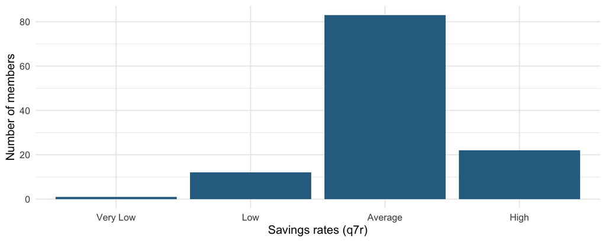

```r
case31 |>
  filter(!is.na(q7r)) |>
  ggplot(aes(x = as_factor(q7r))) +
  geom_bar(fill = "#2C6E91") +
  labs(x = "Savings rates (q7r)", y = "Number of members")
```

$H_0: \mu = 3$ (average) $H_A: \mu \neq 3$

```r
r1 <- t.test(case31$q7r, mu = 3)
r1
```

```
    One Sample t-test

data:  case31$q7r
t = 1.3016, df = 117, p-value = 0.1956
alternative hypothesis: true mean is not equal to 3
95 percent confidence interval:
 2.964639 3.170954
sample estimates:
mean of x
 3.067797
```

## R1: Insights

- Most members (70% of those with an opinion) think the savings rate EFCU pays is **average**.
- The mean is 3.07, which is **not significantly different from 3** (*t*(117) = 1.3, *p* = 0.196).
- **Takeaway:** savings rates aren’t a strong reason to join or stay. Members likely join for convenience (it’s their employer’s credit union) and other services, not for better-than-average returns.

# R2: Why do members borrow elsewhere?

## R2: Overview

- **Construct:** reasons members use loans from other financial institutions
- **Operationalization:**
  - `q8r`: rates the CU charges on loans (1 = Very Low, 5 = Very High)
  - `q30`: “CU loan rates are lower than other institutions” (1 = Strongly Disagree, 5 = Strongly Agree)
- **Scale:** 1–5 Likert-type, treated as approximately interval
- **Statistics:** descriptive statistics, followed by **one-sample t-tests** against 3

## R2: Results

- Frequency
- Plot
- t-tests

```r
freq_tbl(case31, "q8r") |> kable(col.names = c("Loan rates charged (q8r)", "n", "%"))
```

| Loan rates charged (q8r) | n | % |
| --- | --- | --- |
| Very Low | 1 | 0.8 |
| Low | 17 | 13.3 |
| Average | 59 | 46.1 |
| High | 26 | 20.3 |
| Very High | 4 | 3.1 |
| NA | 21 | 16.4 |

```r
freq_tbl(case31, "q30") |> kable(col.names = c("CU rates lower (q30)", "n", "%"))
```

| CU rates lower (q30) | n | % |
| --- | --- | --- |
| Strongly Disagree | 4 | 3.1 |
| Disagree | 27 | 21.1 |
| Uncertain | 59 | 46.1 |
| Agree | 33 | 25.8 |
| Strongly Agree | 5 | 3.9 |

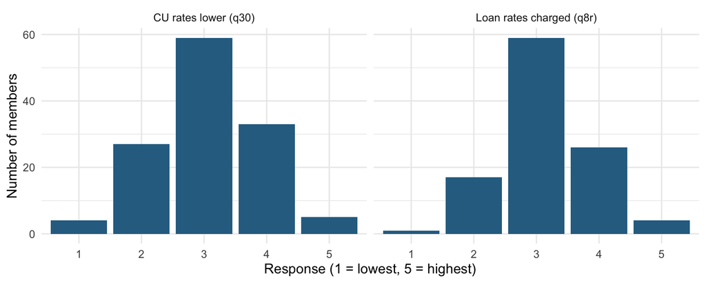

```r
case31 |>
  select(`Loan rates charged (q8r)` = q8r, `CU rates lower (q30)` = q30) |>
  zap_labels() |>
  pivot_longer(everything(), names_to = "item", values_to = "value") |>
  filter(!is.na(value)) |>
  ggplot(aes(x = factor(value))) +
  geom_bar(fill = "#2C6E91") +
  facet_wrap(~item) +
  labs(x = "Response (1 = lowest, 5 = highest)", y = "Number of members")
```

$H_0: \mu = 3$ $H_A: \mu \neq 3$

```r
r2 <- bind_rows(one_t(case31, "q8r"), one_t(case31, "q30"))

r2 |> mutate(p.value = fmt_p(p.value)) |> kable(digits = 3)
```

| variable | mean | mu | t | df | p.value | conf.low | conf.high |
| --- | --- | --- | --- | --- | --- | --- | --- |
| q8r | 3.140 | 3 | 1.913 | 106 | 0.058 | 2.995 | 3.285 |
| q30 | 3.062 | 3 | 0.815 | 127 | 0.416 | 2.911 | 3.214 |

## R2: Insights

- **Loan rates (q8r):** the mean is 3.14, not significantly different from “Average” (*p* = 0.058). About 28% of members think EFCU’s loan rates are high or very high.
- **Rates vs. competitors (q30):** the mean is 3.06, not significantly different from “Uncertain” (*p* = 0.416). Only 30% agree that EFCU’s rates are lower than other institutions’.
- **Takeaway:** members don’t see EFCU’s loan rates as a reason to borrow there. Nothing makes the CU stand out on price, so members have no reason to choose it over a bank. This is a likely reason for the low loan/share ratio.

# R5: How aware are members of CU services?

## R5: Overview

- **Construct:** awareness of services
- **Operationalization:** `q13r`–`q26r` (14 services)
- **Scale:** ordinal (1 = Unaware, 2 = Aware but Have Not Used, 3 = Aware and Have Used)
- **Statistics:** frequency distributions, followed by a **chi-square goodness-of-fit test** for each service

## R5: Demonstration with q13r (Regular share account)

- Frequency
- Plot
- Goodness of fit

```r
freq_tbl(case31, "q13r") |> kable(col.names = c("Regular share account", "n", "%"))
```

| Regular share account | n | % |
| --- | --- | --- |
| Unaware | 83 | 64.8 |
| Aware but Have Not Used | 32 | 25.0 |
| Aware and Have Used | 13 | 10.2 |

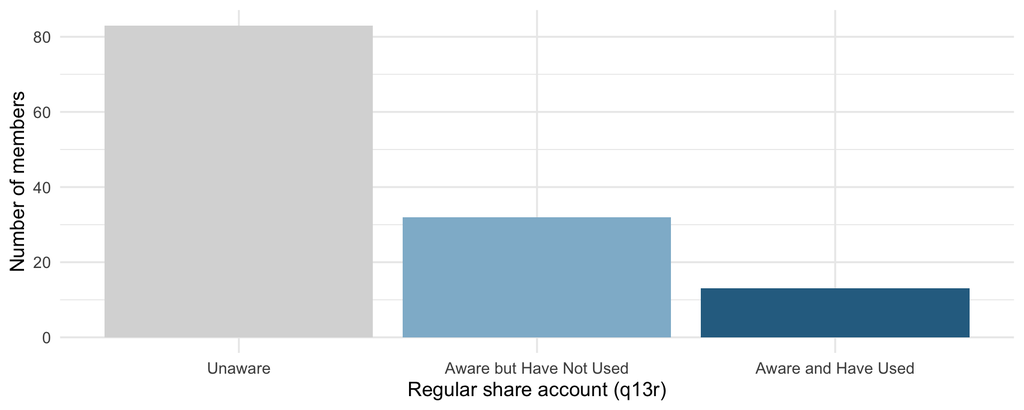

```r
case31 |>
  ggplot(aes(x = as_factor(q13r), fill = as_factor(q13r))) +
  geom_bar(show.legend = FALSE) +
  scale_fill_manual(values = c("#D9D9D9", "#8FB9D1", "#2C6E91")) +
  labs(x = "Regular share account (q13r)", y = "Number of members")
```

$H_0$: the three awareness levels are equally likely (1/3 each)

$H_A$: the awareness levels are not equally likely

```r
table(factor(case31$q13r, levels = 1:3)) |>
  chisq.test(p = c(1/3, 1/3, 1/3))
```

```
    Chi-squared test for given probabilities

data:  table(factor(case31$q13r, levels = 1:3))
X-squared = 61.422, df = 2, p-value = 4.596e-14
```

## R5: All 14 Services

```r
service_labels <- c(
  q13r = "Regular share account", q14r = "Special subaccounts",
  q15r = "Christmas club account", q16r = "IRA",
  q17r = "Master credit card", q18r = "Signature loans",
  q19r = "New car loans", q20r = "Late model car loans",
  q21r = "Older model car loans", q22r = "Household goods loans",
  q23r = "Recreational loans", q24r = "Share collateralized loan",
  q25r = "IRA loans", q26r = "Line of credit loans"
)

r5 <- map_dfr(names(service_labels), \(v) {
  counts <- table(factor(case31[[v]], levels = 1:3))
  test <- chisq.test(counts, p = c(1/3, 1/3, 1/3))
  tibble(
    service = service_labels[[v]],
    `Unaware %` = round(counts[["1"]] / sum(counts) * 100, 1),
    `Aware, not used %` = round(counts[["2"]] / sum(counts) * 100, 1),
    `Aware & used %` = round(counts[["3"]] / sum(counts) * 100, 1),
    `Chi-square` = round(unname(test$statistic), 2),
    df = unname(test$parameter),
    p = fmt_p(test$p.value)
  )
})

r5 |> arrange(desc(`Aware & used %`)) |> kable()
```

| service | Unaware % | Aware, not used % | Aware & used % | Chi-square | df | p |
| --- | --- | --- | --- | --- | --- | --- |
| Master credit card | 11.7 | 44.5 | 43.8 | 26.92 | 2 | < .001 |
| Line of credit loans | 0.0 | 62.5 | 37.5 | 76.00 | 2 | < .001 |
| IRA | 27.3 | 50.0 | 22.7 | 16.42 | 2 | < .001 |
| New car loans | 3.9 | 77.3 | 18.8 | 115.80 | 2 | < .001 |
| Signature loans | 3.9 | 81.2 | 14.8 | 134.55 | 2 | < .001 |
| Late model car loans | 9.4 | 79.7 | 10.9 | 123.81 | 2 | < .001 |
| Regular share account | 64.8 | 25.0 | 10.2 | 61.42 | 2 | < .001 |
| Recreational loans | 43.0 | 46.9 | 10.2 | 31.23 | 2 | < .001 |
| Special subaccounts | 35.9 | 54.7 | 9.4 | 39.81 | 2 | < .001 |
| Older model car loans | 25.8 | 64.8 | 9.4 | 62.36 | 2 | < .001 |
| Christmas club account | 32.8 | 58.6 | 8.6 | 48.02 | 2 | < .001 |
| Household goods loans | 28.9 | 62.5 | 8.6 | 56.92 | 2 | < .001 |
| IRA loans | 60.9 | 35.9 | 3.1 | 64.56 | 2 | < .001 |
| Share collateralized loan | 53.9 | 44.5 | 1.6 | 59.83 | 2 | < .001 |

## R5: Awareness Chart

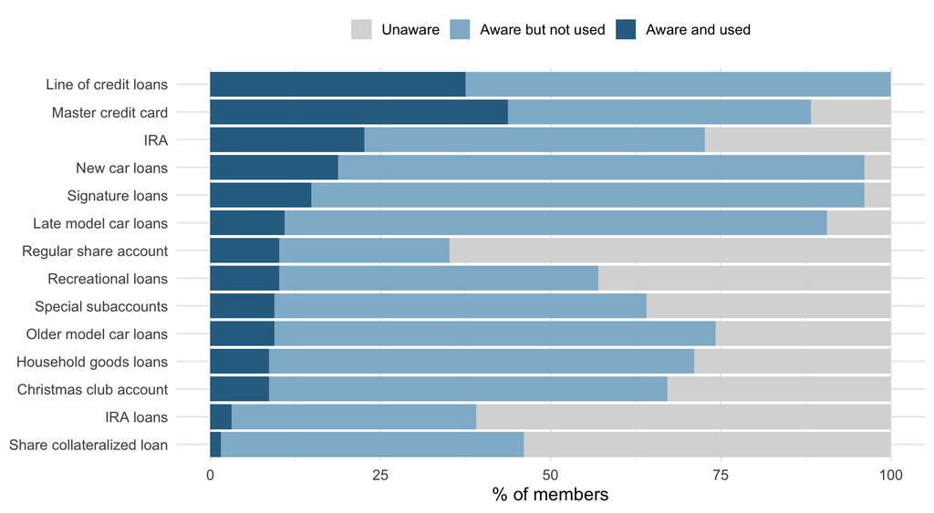

```r
case31 |>
  select(all_of(names(service_labels))) |>
  pivot_longer(everything(), names_to = "item", values_to = "level") |>
  mutate(
    service = service_labels[item],
    level = factor(level, levels = 1:3,
                   labels = c("Unaware", "Aware but not used", "Aware and used"))
  ) |>
  count(service, level) |>
  group_by(service) |>
  mutate(pct = n / sum(n) * 100) |>
  ggplot(aes(x = pct, y = reorder(service, pct * (level == "Aware and used")), fill = level)) +
  geom_col() +
  scale_fill_manual(values = c("#D9D9D9", "#8FB9D1", "#2C6E91")) +
  labs(x = "% of members", y = NULL, fill = NULL) +
  theme(legend.position = "top")
```

## R5: Insights

- For **all 14 of 14 services**, awareness levels are significantly different from an even split (*p* < .05), so members aren’t spread evenly across the levels.
- **Use is low across the board.** 11 of 14 services have been used by fewer than 20% of members. The most used is the Master credit card (43.8%).
- **For most loans, the issue is use, not awareness.** Most members know about new car loans and signature loans, but very few have used them.
- Some services (IRA loans, share collateralized loans, recreational loans) have high **unawareness**, so they need basic promotion.
- One result looks odd: 65% are coded **unaware of the regular share account**, even though members normally need one to join. This may be a coding issue in the original data and is worth checking against the paper surveys.
- **Takeaway:** EFCU should promote its loan products and give members a reason to choose them (ties back to R2’s rate perception).

# R6: How effectively is the CU operated?

## R6: Overview

- **Construct:** attitudes toward operational effectiveness
- **Operationalization and statistics:**

| Variable(s) | Measure | Scale | Statistics |
| --- | --- | --- | --- |
| `q9`, `q10r` | Statement frequency, statement accuracy | Ordinal | Frequencies / chi-square goodness of fit |
| `q11`, `q12` | Statements understandable, account kept confidential | Nominal (yes/no) | Frequencies / chi-square goodness of fit |
| `q31`–`q34` | Confidentiality, prompt processing, meets needs, simple applications | Interval (1–5) | Descriptives / one-sample t-test |
| `q37r` | Overall rating of management | Interval (1–5) | Descriptives / one-sample t-test |

## R6: Account Statements (q9, q10r, q11, q12)

- Frequencies
- Goodness of fit

```r
freq_tbl(case31, "q9") |> kable(col.names = c("Statement frequency (q9)", "n", "%"))
```

| Statement frequency (q9) | n | % |
| --- | --- | --- |
| About Right | 99 | 77.3 |
| Not Often Enough | 29 | 22.7 |

```r
freq_tbl(case31, "q10r") |> kable(col.names = c("Statement accuracy (q10r)", "n", "%"))
```

| Statement accuracy (q10r) | n | % |
| --- | --- | --- |
| Poor | 2 | 1.6 |
| Fair | 4 | 3.1 |
| Good | 54 | 42.2 |
| Excellent | 68 | 53.1 |

```r
freq_tbl(case31, "q11") |> kable(col.names = c("Statements understandable (q11)", "n", "%"))
```

| Statements understandable (q11) | n | % |
| --- | --- | --- |
| Yes | 125 | 97.7 |
| No | 3 | 2.3 |

```r
freq_tbl(case31, "q12") |> kable(col.names = c("Account confidential (q12)", "n", "%"))
```

| Account confidential (q12) | n | % |
| --- | --- | --- |
| Yes | 74 | 57.8 |
| No | 32 | 25.0 |
| NA | 22 | 17.2 |

$H_0$: response categories are equally likely $H_A$: they are not

```r
gof <- function(var, label) {
  counts <- table(case31[[var]])  # observed categories only
  test <- chisq.test(counts)
  tibble(measure = label, categories = length(counts),
         `Chi-square` = unname(test$statistic), df = unname(test$parameter),
         p = test$p.value)
}

r6_gof <- bind_rows(
  gof("q9", "Statement frequency (q9)"),
  gof("q10r", "Statement accuracy (q10r)"),
  gof("q11", "Statements understandable (q11)"),
  gof("q12", "Account confidential (q12)")
)

r6_gof |> mutate(p = fmt_p(p)) |> kable(digits = 2)
```

| measure | categories | Chi-square | df | p |
| --- | --- | --- | --- | --- |
| Statement frequency (q9) | 2 | 38.28 | 1 | < .001 |
| Statement accuracy (q10r) | 4 | 108.25 | 3 | < .001 |
| Statements understandable (q11) | 2 | 116.28 | 1 | < .001 |
| Account confidential (q12) | 2 | 16.64 | 1 | < .001 |

Tested on the categories members actually chose. For q9, no one chose “Too Often”, “Very Often”, or “Never”.

## R6: Operations Items and Overall Rating (q31–q34, q37r)

- Descriptives
- Plot
- t-tests

```r
ops_labels <- c(
  q31 = "Keeps information confidential (q31)",
  q32 = "Prompt loan processing (q32)",
  q33 = "Services meet members' needs (q33)",
  q34 = "Loan applications simple (q34)",
  q37r = "Overall rating of management (q37r)"
)

case31 |>
  select(all_of(names(ops_labels))) |>
  zap_labels() |>
  pivot_longer(everything(), names_to = "variable", values_to = "value") |>
  summarise(
    n = sum(!is.na(value)),
    mean = mean(value, na.rm = TRUE),
    sd = sd(value, na.rm = TRUE),
    `% agree / good+` = mean(value >= 4, na.rm = TRUE) * 100,
    .by = variable
  ) |>
  mutate(variable = ops_labels[variable]) |>
  kable(digits = 2)
```

| variable | n | mean | sd | % agree / good+ |
| --- | --- | --- | --- | --- |
| Keeps information confidential (q31) | 128 | 3.95 | 0.68 | 78.12 |
| Prompt loan processing (q32) | 128 | 3.72 | 0.79 | 60.16 |
| Services meet members’ needs (q33) | 128 | 3.59 | 0.68 | 59.38 |
| Loan applications simple (q34) | 128 | 3.46 | 0.78 | 57.81 |
| Overall rating of management (q37r) | 121 | 4.07 | 0.73 | 84.30 |

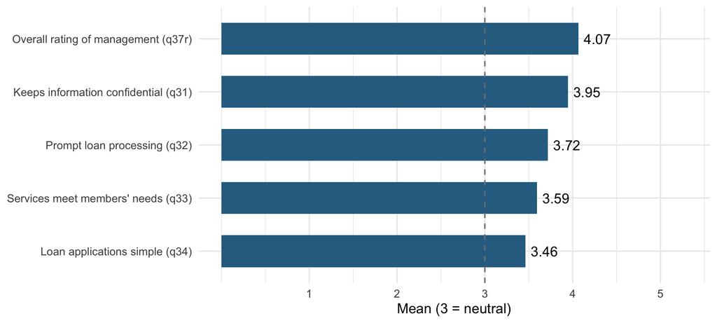

```r
case31 |>
  select(all_of(names(ops_labels))) |>
  zap_labels() |>
  pivot_longer(everything(), names_to = "variable", values_to = "value") |>
  summarise(mean = mean(value, na.rm = TRUE), .by = variable) |>
  mutate(variable = ops_labels[variable]) |>
  ggplot(aes(x = mean, y = reorder(variable, mean))) +
  geom_col(fill = "#2C6E91", width = 0.6) +
  geom_text(aes(label = sprintf("%.2f", mean)), hjust = -0.2) +
  geom_vline(xintercept = 3, linetype = "dashed", color = "gray50") +
  scale_x_continuous(limits = c(0, 5.3), breaks = 1:5) +
  labs(x = "Mean (3 = neutral)", y = NULL)
```

$H_0: \mu = 3$ (neutral) $H_A: \mu \neq 3$

```r
r6_t <- map_dfr(names(ops_labels), \(v) one_t(case31, v)) |>
  mutate(variable = ops_labels[variable])

r6_t |> mutate(p.value = fmt_p(p.value)) |> kable(digits = 3)
```

| variable | mean | mu | t | df | p.value | conf.low | conf.high |
| --- | --- | --- | --- | --- | --- | --- | --- |
| Keeps information confidential (q31) | 3.945 | 3 | 15.742 | 127 | < .001 | 3.826 | 4.064 |
| Prompt loan processing (q32) | 3.719 | 3 | 10.254 | 127 | < .001 | 3.580 | 3.857 |
| Services meet members’ needs (q33) | 3.594 | 3 | 9.866 | 127 | < .001 | 3.475 | 3.713 |
| Loan applications simple (q34) | 3.461 | 3 | 6.663 | 127 | < .001 | 3.324 | 3.598 |
| Overall rating of management (q37r) | 4.066 | 3 | 16.125 | 120 | < .001 | 3.935 | 4.197 |

## R6: Insights

- **Statements are a strength.** 77% say statement frequency is about right (the rest say “not often enough”), 95% rate accuracy good or excellent, and 98% find statements easy to understand.
- **Confidentiality:** 70% say yes to q12, and q31 is rated well above neutral.
- **All four operations items (q31–q34) are significantly above neutral** (*p* < .05), but **meeting needs (q33)** and **simple applications (q34)** score the lowest. Those are the areas to improve.
- **Overall rating (q37r):** the mean is 4.07 (*p* < .001 vs. 3), and 84% rate management good or excellent.
- **Takeaway:** members think the CU runs well overall. The weak spots are on the loan side (processing, applications, meeting needs), not day-to-day operations.

# Summary

## Summary of Findings

| RQ | Analysis | Key finding |
| --- | --- | --- |
| **R1** | One-sample t-test | Savings rates seen as **average**; not a strong reason to join |
| **R2** | One-sample t-tests | Loan rates **not seen as lower** than competitors; no price reason to borrow at EFCU |
| **R5** | Chi-square goodness of fit | **Low use** of almost every service; many loans are known but not used |
| **R6** | Chi-square GOF / one-sample t-tests | Operations and statements rated **positively**; loan applications and meeting needs are weakest |

## Recommendations

1. **Review loan pricing** against local competitors, and clearly communicate rates where EFCU is competitive.
2. **Promote loan products** with a focus on *why* members should choose EFCU, since awareness is often already there.
3. **Simplify loan applications** and speed up processing to remove friction for borrowers.
4. **Keep strengths visible:** accurate statements, confidentiality, and solid management are good selling points.

## Limitations

- Small sample (128 usable responses) and no demographic variables
- Likert items treated as approximately interval
- Some items have missing data (e.g., q8r is missing 16% of its answers)
- Results describe one survey at one point in time

# Appendix

## Links

- [GitHub Repo](https://github.com/rsabilla/IC11-2-Case-31-Summary-R1-R2-R5-R6)
- [GitHub Pages](https://rsabilla.github.io/IC11-2-Case-31-Summary-R1-R2-R5-R6/)